# Tugas Praktikum 6 ARIMA

Arifatu Dzikra

2026-09-28

# 1. Packages

```r
library(readxl)
library(ggplot2)
library(tsibble)
library(tseries)
library(MASS)
library(forecast)
library(TSA)
library(TTR)
library(aTSA)
library(graphics)
library(lmtest)
library(car)
```

# 2. Impor dan Pembagian Data

Data yang digunakan adalah suhu rata-rata kota bogor sebanyak 500 observasi akhir. Pada analisis ini, data dibaca dari berkas Excel dan dibagi menjadi data latih (train) sebesar 80% (400 observasi) dan data uji (test) sebesar 20% (100 observasi).

```r
# Mengimpor data
path_data <- "D:/IPB UNIVERSITY/KULIAH/SEMESTER 5/MPDW/Metode Peramalan Deret Waktu/Data/data suhu bogor 500 akhir.xlsx"

# Membaca Data
if (file.exists(path_data)) {
  datasuhu_raw <- read_excel(path_data)
} else {
  datasuhu_raw <- read_excel("data suhu bogor 500 akhir.xlsx")
}

# Mengambil Kolom Suhu
if ("Suhu" %in% colnames(datasuhu_raw)) {
  datasuhu <- datasuhu_raw$Suhu
} else {
  datasuhu <- datasuhu_raw[[ncol(datasuhu_raw)]]
}

# Mengambil 500 amatan
datasuhu <- datasuhu[1:500]
datasuhu.ts <- ts(datasuhu)

# Pembagian Data Train (400 observasi) dan Data Test (100 observasi)
suhutrain <- datasuhu[1:400]
train.ts  <- ts(suhutrain)

suhutest <- datasuhu[401:500]
test.ts  <- ts(suhutest)
```

# 3. Eksplorasi Data

Sebelum masuk ke tahap pemodelan ARIMA, dilakukan eksplorasi visual menggunakan plot deret waktu untuk mengamati karakteristik dan pola pergerakan data suhu.

## 3.1. Plot Data Penuh (500 Amatan)

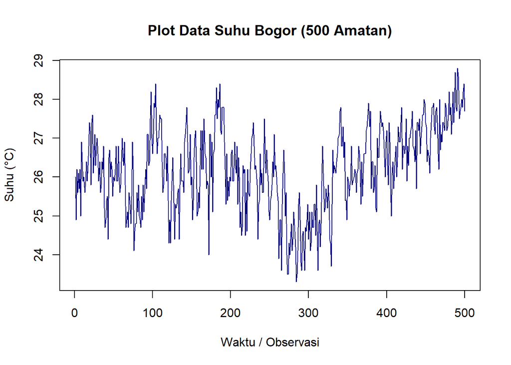

```r
plot.ts(datasuhu.ts,
        col = "navyblue",
        lty = 1,
        xlab = "Waktu / Observasi",
        ylab = "Suhu (°C)",
        main = "Plot Data Suhu Bogor (500 Amatan)")
```

Plot deret waktu dari data suhu Bogor sebanyak 500 amatan menunjukkan fluktuasi harian yang berada pada rentang $23{,}5^\circ\text{C}$ hingga $29{,}0^\circ\text{C}$. Secara visual, data memperlihatkan adanya pergerakan gelombang dan pola tren kenaikan di akhir periode amatan.

## 3.2. Plot Data Latih (Train Set)

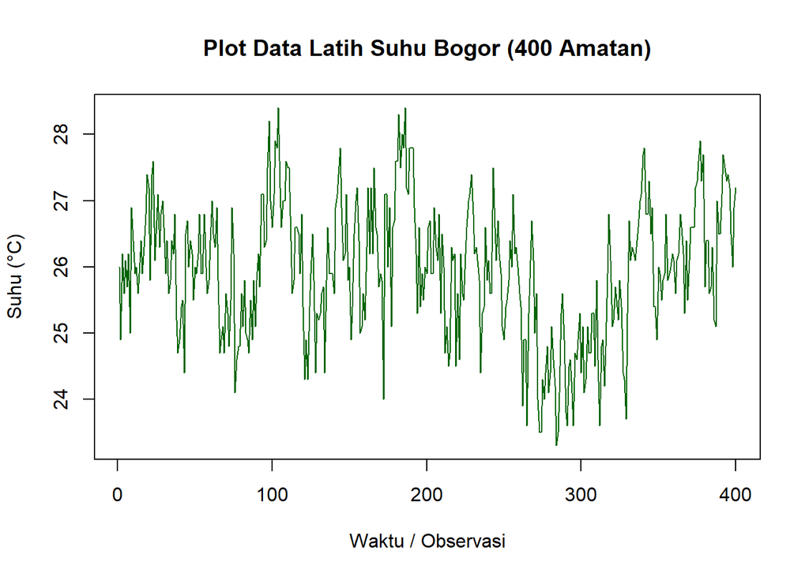

```r
plot.ts(train.ts,
        col = "darkgreen",
        lty = 1,
        xlab = "Waktu / Observasi",
        ylab = "Suhu (°C)",
        main = "Plot Data Latih Suhu Bogor (400 Amatan)")
```

## 3.3. Plot Data Uji (Test Set)

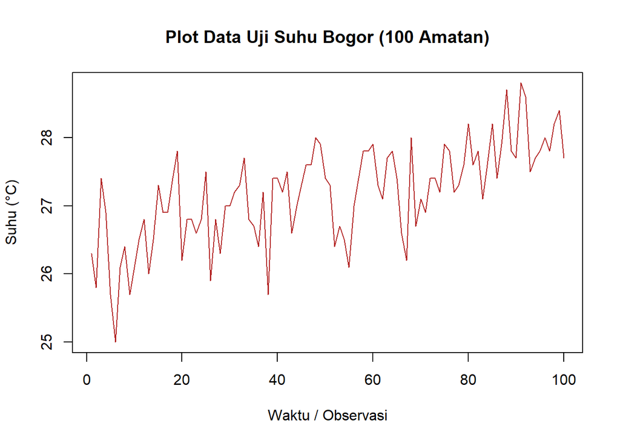

```r
plot.ts(test.ts,
        col = "firebrick",
        lty = 1,
        xlab = "Waktu / Observasi",
        ylab = "Suhu (°C)",
        main = "Plot Data Uji Suhu Bogor (100 Amatan)")
```

100 amatan terakhir ($t = 401 \dots 500$) yang disisihkan untuk pengujian performa peramalan. Data uji menunjukkan tren kenaikan suhu dari kisaran $25{,}0^\circ\text{C}$ hingga mencapai $28{,}8^\circ\text{C}$.

# 4. Uji Stasioneritas Data Latih

## 4.1. Stasioneritas Rataan

### 4.1.1. Plot ACF

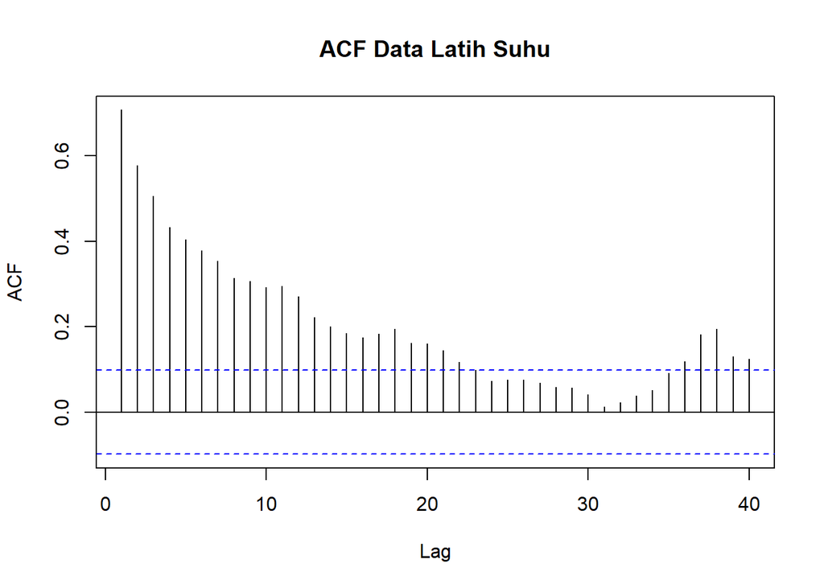

```r
acf(train.ts, main = "ACF Data Latih Suhu", lag.max = 40)
```

Plot ACF pada data latih menunjukkan nilai autokorelasi yang tinggi pada lag awal ($\approx 0{,}72$) dan meluruh secara perlahan (tails off slowly) hingga melewati batas garis signifikan biru. Pola peluruhan lambat ini secara visual mengindikasikan bahwa data latih belum stasioner dalam rataan.

### 4.1.2. Uji Formal ADF (Augmented Dickey-Fuller)

Hipotesis uji ADF:

- $H_0$: Data tidak stasioner dalam rataan (memiliki akar unit)
- $H_1$ : Data stasioner dalam rataan

```r
tseries::adf.test(train.ts)
```

```
##
##  Augmented Dickey-Fuller Test
##
## data:  train.ts
## Dickey-Fuller = -3.8621, Lag order = 7, p-value = 0.0161
## alternative hypothesis: stationary
```

Hasil uji ADF pada data latih menghasilkan nilai statistik Dickey-Fuller = $-3{,}8621$ dengan lag order = $7$ dan $p\text{-value} = 0{,}0161$.

- Keputusan: Karena $p\text{-value} = 0{,}0161 < 0{,}05$, maka keputusan uji adalah Tolak $H_0$ pada taraf nyata 5%.
- Kesimpulan: Uji ADF secara formal menyatakan data stasioner dalam rataan. Namun, mempertimbangkan plot ACF yang meluruh lambat (tails off slowly), proses diferensiasi (differencing $d=1$) tetap perlu dipertimbangkan pada tahap pemodelan untuk melepaskan efek tren tersembunyi.

## 4.2. Stasioneritas Ragam (Box-Cox)

Pemeriksaan kestasioneran ragam dilakukan menggunakan transformasi Box-Cox pada data latih.

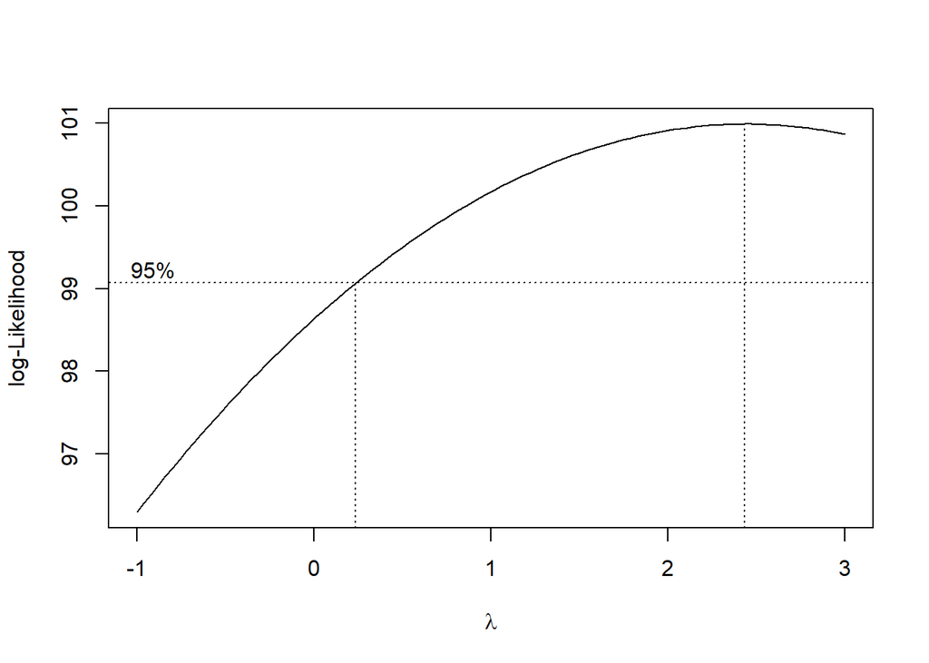

```r
index <- seq_along(train.ts)

# Plot Box-Cox
bc <- boxcox(train.ts ~ index, lambda = seq(-1, 3, by = 0.1))
```

```r
# Nilai lambda optimum
lambda_opt <- bc$x[which.max(bc$y)]
print(paste("Lambda Optimum:", round(lambda_opt, 4)))
```

```
## [1] "Lambda Optimum: 2.4343"
```

```r
# Selang kepercayaan 95% untuk lambda
ci_lambda <- bc$x[bc$y > max(bc$y) - 0.5 * qchisq(0.95, df = 1)]

ci_lower <- min(ci_lambda)
ci_upper <- max(ci_lambda)

c(Batas_Bawah = ci_lower, Batas_Atas = ci_upper)
```

```
## Batas_Bawah  Batas_Atas
##   0.2525253   3.0000000
```

Berdasarkan pengujian Box-Cox pada data latih, diperoleh:

- Nilai $\lambda$ optimum (Lambda Optimum): $2{,}4343$
- Selang Kepercayaan 95% ($95\%\text{ CI}$) untuk $\lambda$: $[0{,}2525 \text{ ; } 3{,}0000]$

Karena selang kepercayaan 95% untuk $\lambda$ memuat angka 1 ($1 \in [0{,}2525; 3{,}0000]$), maka disimpulkan bahwa data latih sudah stasioner dalam ragam. Oleh karena itu, data tidak memerlukan transformasi Box-Cox sebelum masuk ke tahap identifikasi model ARIMA.

# 5. Penanganan Ketidakstasioneran Data

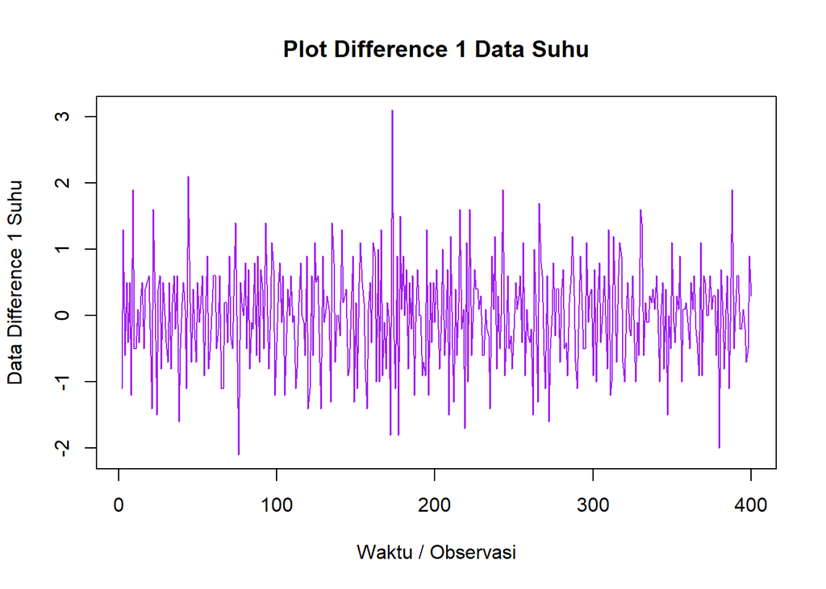

```r
# Differencing pertama
train.diff <- diff(train.ts, differences = 1)

# Plot hasil differencing
plot.ts(train.diff,
        col = "purple",
        lty = 1,
        xlab = "Waktu / Observasi",
        ylab = "Data Difference 1 Suhu",
        main = "Plot Difference 1 Data Suhu")
```

Berdasarkan plot data hasil differencing, terlihat data sudah bergerak di sekitar nilai tengah tertentu (tidak ada tren naik/turun yang jelas), yang mengindikasikan data sudah stasioner dalam rataan.

## 5.1. Plot ACF Setelah Differencing

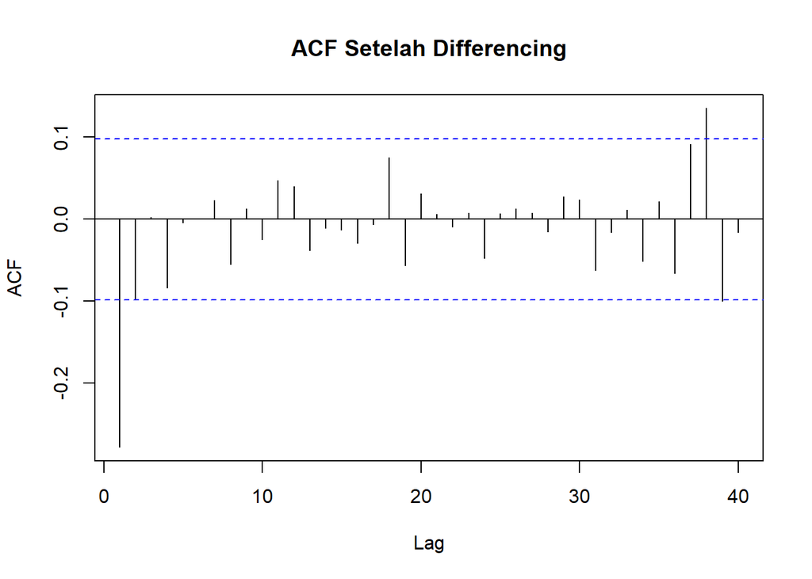

```r
acf(train.diff, main = "ACF Setelah Differencing", lag.max = 40)
```

Berdasarkan plot ACF setelah differencing, terlihat autokorelasi sudah meluruh lebih cepat dibandingkan sebelumnya, menandakan ketidakstasioneran dalam rataan sudah tertangani.

## 5.2. Uji ADF Setelah Differencing

```r
tseries::adf.test(train.diff)
```

```
##
##  Augmented Dickey-Fuller Test
##
## data:  train.diff
## Dickey-Fuller = -9.9737, Lag order = 7, p-value = 0.01
## alternative hypothesis: stationary
```

Hipotesis uji ADF:

- $H_0$: Data tidak stasioner dalam rataan
- $H_1$: Data stasioner dalam rataan

Berdasarkan uji ADF setelah differencing, diperoleh p-value yang lebih kecil dari taraf nyata 5%, sehingga tolak $H_0$ atau data stasioner dalam rataan. Dengan demikian, ketidakstasioneran data sudah berhasil ditangani.

## 5.3. Cek Stasioneritas Ragam Setelah Differencing (Box-Cox)

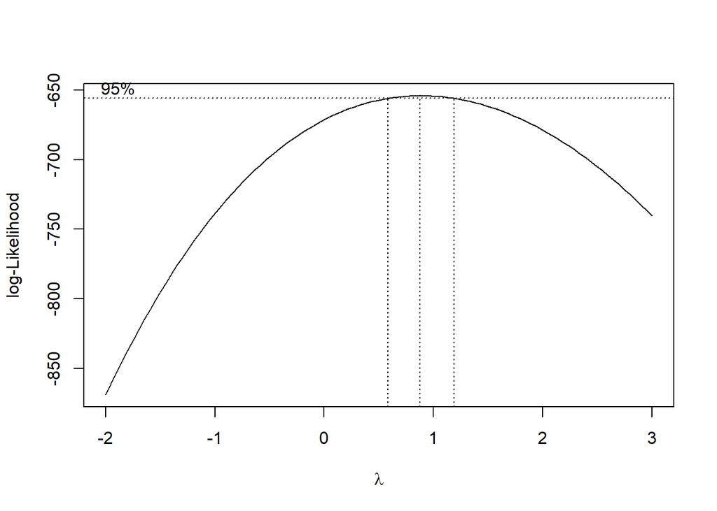

```r
# Sesuaikan panjang index karena differencing menghilangkan 1 observasi
index_diff <- seq_along(train.diff)

# Cek nilai negatif. Jika ada, tambahkan konstanta
min_val <- min(train.diff)

if (min_val <= 0) {
  c_shift <- abs(min_val) + 1
  train.diff_shifted <- train.diff + c_shift
} else {
  train.diff_shifted <- train.diff
}

# Plot Box-Cox pada data yang sudah di-shift
bc_diff <- boxcox(train.diff_shifted ~ index_diff, lambda = seq(-2, 3, by = 0.1))
```

```r
# Nilai lambda optimum
lambda_opt_diff <- bc_diff$x[which.max(bc_diff$y)]
print(paste("Lambda optimum setelah diff:", round(lambda_opt_diff, 4)))
```

```
## [1] "Lambda optimum setelah diff: 0.8788"
```

```r
# Selang kepercayaan 95%
ci_lambda_diff <- bc_diff$x[bc_diff$y > max(bc_diff$y) - 0.5 * qchisq(0.95, df = 1)]

c(Batas_Bawah = min(ci_lambda_diff), Batas_Atas = max(ci_lambda_diff))
```

```
## Batas_Bawah  Batas_Atas
##   0.6262626   1.1818182
```

Karena selang kepercayaan 95% untuk λ memuat angka 1, maka data hasil differencing sudah stasioner dalam ragam dan tidak memerlukan transformasi tambahan.

# 6. Identifikasi Model

## 6.1. Plot ACF dan PACF

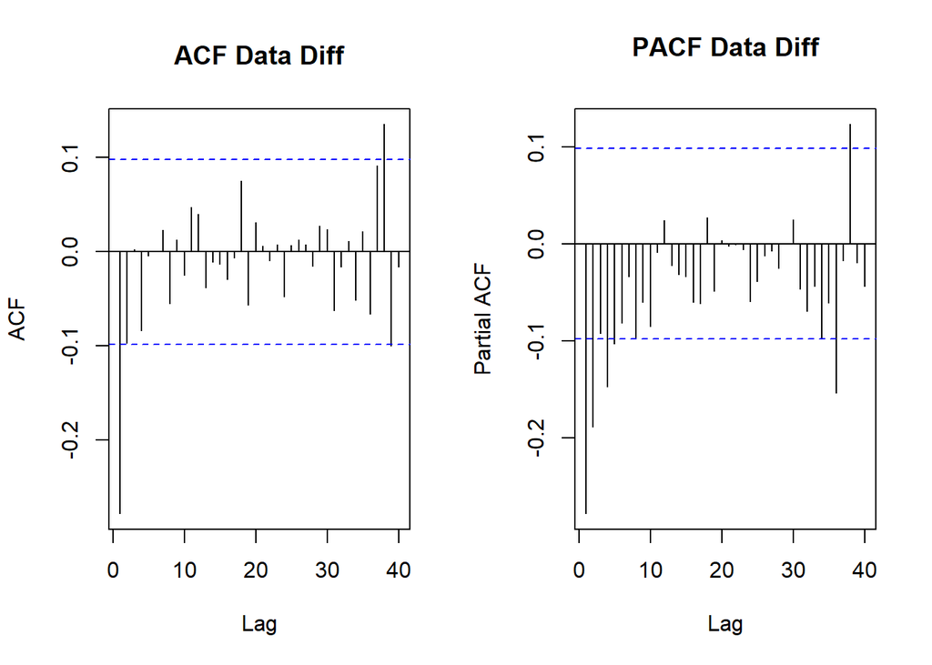

```r
par(mfrow = c(1, 2))
acf(train.diff, main = "ACF Data Diff", lag.max = 40)
pacf(train.diff, main = "PACF Data Diff", lag.max = 40)
```

```r
par(mfrow = c(1, 1))
```

Berdasarkan Plot ACF, terlihat *cuts off* pada lag ke-1 sehingga dapat kita asumsikan model yang terbentuk adalah ARIMA(0,1,1). Selanjutnya, berdasarkan plot PACF, terlihat *cuts off* pada lag kedua sehingga model yang terbentuk adalah ARIMA(2,1,0). Selain dengan plot ACF dan PACF, penentuan spesifikasi model dilakukan dengan *extended ACF* (EACF) berikut ini.

## 6.2. Plot EACF

```r
TSA::eacf(train.diff)
```

```
## AR/MA
##   0 1 2 3 4 5 6 7 8 9 10 11 12 13
## 0 x o o o o o o o o o o  o  o  o
## 1 x x o o o o o o o o o  o  o  o
## 2 x x x o o o o o o o o  o  o  o
## 3 x x x x o o o o o o o  o  o  o
## 4 x o x x o o o o o o o  o  o  o
## 5 x x o x x o o o o o o  o  o  o
## 6 x x o x o x o o o o o  o  o  o
## 7 x x x x o x o x o o o  o  o  o
```

Menggunakan plot EACF, dapat diambil beberapa model dengan melihat ujung segitiga yang terbentuk, antara lain ARIMA(0,1,1), ARIMA(1,1,2), ARIMA(2,1,3), dan ARIMA(3,1,4).

## 6.3. Pendugaan Parameter

Selanjutnya akan dilakukan pendugaan parameter kelima model ARIMA yang terbentuk sebelumnya. Pendugaan dilakukan dengan fungsi `Arima()` yang dilanjutkan dengan melihat nilai AIC pada ringkasan data dan melihat signifikansi parameter.

```r
# Pendugaan Parameter Model
# ARIMA(0,1,1)
model1.da <- Arima(train.diff, order = c(0,0,1), method = "ML")
summary(model1.da)
```

```
## Series: train.diff
## ARIMA(0,0,1) with non-zero mean
##
## Coefficients:
##           ma1    mean
##       -0.4453  0.0031
## s.e.   0.0603  0.0202
##
## sigma^2 = 0.5311:  log likelihood = -439.01
## AIC=884.03   AICc=884.09   BIC=896
##
## Training set error measures:
##                         ME     RMSE       MAE MPE MAPE      MASE       ACF1
## Training set -0.0007149262 0.726927 0.5832539 NaN  Inf 0.5859037 0.07322255
```

```r
lmtest::coeftest(model1.da)
```

```
##
## z test of coefficients:
##
##             Estimate Std. Error z value  Pr(>|z|)
## ma1       -0.4453117  0.0602571 -7.3902 1.466e-13 ***
## intercept  0.0031025  0.0202270  0.1534    0.8781
## ---
## Signif. codes:  0 '***' 0.001 '**' 0.01 '*' 0.05 '.' 0.1 ' ' 1
```

```r
# ARIMA(1,1,2) -- Tambahan dari kombinasi ACF & PACF
model2.da <- Arima(train.diff, order = c(1,0,2), method = "ML")
summary(model2.da)
```

```
## Series: train.diff
## ARIMA(1,0,2) with non-zero mean
##
## Coefficients:
##          ar1      ma1     ma2    mean
##       0.7021  -1.1233  0.1723  0.0018
## s.e.  0.1068   0.1278  0.1016  0.0060
##
## sigma^2 = 0.5015:  log likelihood = -426.87
## AIC=863.74   AICc=863.89   BIC=883.68
##
## Training set error measures:
##                       ME      RMSE       MAE MPE MAPE      MASE        ACF1
## Training set 0.001689243 0.7046108 0.5672261 NaN  Inf 0.5698031 0.003741433
```

```r
lmtest::coeftest(model2.da)
```

```
##
## z test of coefficients:
##
##             Estimate Std. Error z value  Pr(>|z|)
## ar1        0.7020785  0.1067773  6.5752  4.86e-11 ***
## ma1       -1.1232971  0.1277855 -8.7905 < 2.2e-16 ***
## ma2        0.1722715  0.1015779  1.6960   0.08989 .
## intercept  0.0018004  0.0060284  0.2987   0.76521
## ---
## Signif. codes:  0 '***' 0.001 '**' 0.01 '*' 0.05 '.' 0.1 ' ' 1
```

```r
# ARIMA(2,1,0)
model3.da <- Arima(train.diff, order = c(2,0,0), method = "ML")
summary(model3.da)
```

```
## Series: train.diff
## ARIMA(2,0,0) with non-zero mean
##
## Coefficients:
##           ar1      ar2    mean
##       -0.3307  -0.1893  0.0030
## s.e.   0.0492   0.0494  0.0241
##
## sigma^2 = 0.5368:  log likelihood = -440.61
## AIC=889.21   AICc=889.31   BIC=905.17
##
## Training set error measures:
##                         ME      RMSE       MAE MPE MAPE      MASE        ACF1
## Training set -0.0005733344 0.7298946 0.5849051 NaN  Inf 0.5875624 -0.01764486
```

```r
lmtest::coeftest(model3.da)
```

```
##
## z test of coefficients:
##
##             Estimate Std. Error z value  Pr(>|z|)
## ar1       -0.3307382  0.0492210 -6.7194 1.824e-11 ***
## ar2       -0.1892678  0.0493915 -3.8320 0.0001271 ***
## intercept  0.0030197  0.0240682  0.1255 0.9001561
## ---
## Signif. codes:  0 '***' 0.001 '**' 0.01 '*' 0.05 '.' 0.1 ' ' 1
```

```r
# ARIMA(2,1,3)
model4.da <- Arima(train.diff, order = c(2,0,3), method = "ML")
summary(model4.da)
```

```
## Series: train.diff
## ARIMA(2,0,3) with non-zero mean
##
## Coefficients:
##           ar1     ar2      ma1      ma2     ma3    mean
##       -0.0247  0.5698  -0.3893  -0.7420  0.2015  0.0017
## s.e.   0.2714  0.1662   0.2764   0.2371  0.0922  0.0057
##
## sigma^2 = 0.5019:  log likelihood = -426.04
## AIC=866.07   AICc=866.36   BIC=894
##
## Training set error measures:
##                      ME      RMSE       MAE MPE MAPE      MASE        ACF1
## Training set 0.00161265 0.7031104 0.5662846 NaN  Inf 0.5688574 -0.00053784
```

```r
lmtest::coeftest(model4.da)
```

```
##
## z test of coefficients:
##
##             Estimate Std. Error z value  Pr(>|z|)
## ar1       -0.0246600  0.2714192 -0.0909 0.9276073
## ar2        0.5698448  0.1662458  3.4277 0.0006087 ***
## ma1       -0.3892530  0.2764425 -1.4081 0.1591076
## ma2       -0.7419835  0.2370503 -3.1301 0.0017477 **
## ma3        0.2015480  0.0922115  2.1857 0.0288364 *
## intercept  0.0016771  0.0056932  0.2946 0.7683096
## ---
## Signif. codes:  0 '***' 0.001 '**' 0.01 '*' 0.05 '.' 0.1 ' ' 1
```

```r
# ARIMA(3,1,4)
model5.da <- Arima(train.diff, order = c(3,0,4), method = "ML")
summary(model5.da)
```

```
## Series: train.diff
## ARIMA(3,0,4) with non-zero mean
##
## Coefficients:
```

```
##           ar1     ar2     ar3      ma1      ma2     ma3     ma4    mean
##       -0.1301  0.5656  0.0612  -0.2838  -0.7814  0.1217  0.0214  0.0017
## s.e.      NaN  0.0681     NaN      NaN      NaN     NaN     NaN  0.0057
##
## sigma^2 = 0.5045:  log likelihood = -426.04
## AIC=870.07   AICc=870.54   BIC=905.97
##
## Training set error measures:
##                      ME      RMSE       MAE MPE MAPE      MASE          ACF1
## Training set 0.00165427 0.7031106 0.5662877 NaN  Inf 0.5688604 -0.0005865525
```

```r
lmtest::coeftest(model5.da)
```

```
##
## z test of coefficients:
##
##             Estimate Std. Error z value Pr(>|z|)
## ar1       -0.1300563        NaN     NaN      NaN
## ar2        0.5656324  0.0681396  8.3011   <2e-16 ***
## ar3        0.0611992        NaN     NaN      NaN
## ma1       -0.2838024        NaN     NaN      NaN
## ma2       -0.7814287        NaN     NaN      NaN
## ma3        0.1216978        NaN     NaN      NaN
## ma4        0.0213503        NaN     NaN      NaN
## intercept  0.0016705  0.0056941  0.2934   0.7692
## ---
## Signif. codes:  0 '***' 0.001 '**' 0.01 '*' 0.05 '.' 0.1 ' ' 1
```

Berdasarkan hasil pendugaan parameter pada 5 kandidat model tentatif awal hasil identifikasi EACF, diperoleh temuan sebagai berikut:

Rasionalisasi Penambahan Model ARIMA(1,1,1):

```r
model_tentatif <- data.frame(
  Model = c("ARIMA(0,1,1)", "ARIMA(1,1,2)", "ARIMA(2,1,0)",
            "ARIMA(2,1,3)", "ARIMA(3,1,4)"),
  AIC   = c(AIC(model1.da), AIC(model2.da), AIC(model3.da),
            AIC(model4.da), AIC(model5.da)),
  BIC   = c(BIC(model1.da), BIC(model2.da), BIC(model3.da),
            BIC(model4.da), BIC(model5.da))
)

model_tentatif[order(model_tentatif$AIC), ]
```

```
##          Model      AIC      BIC
## 2 ARIMA(1,1,2) 863.7352 883.6800
## 4 ARIMA(2,1,3) 866.0736 893.9964
## 5 ARIMA(3,1,4) 870.0736 905.9743
## 1 ARIMA(0,1,1) 884.0285 895.9953
## 3 ARIMA(2,1,0) 889.2120 905.1678
```

```r
# Coba model ARIMA(1,1,1)
model_tambahan <- Arima(train.diff, order = c(1,0,1), method = "ML")
summary(model_tambahan)
```

```
## Series: train.diff
## ARIMA(1,0,1) with non-zero mean
##
## Coefficients:
##          ar1      ma1    mean
##       0.4988  -0.8843  0.0023
## s.e.  0.0819   0.0522  0.0083
##
## sigma^2 = 0.5034:  log likelihood = -428.02
## AIC=864.05   AICc=864.15   BIC=880.01
##
## Training set error measures:
##                        ME      RMSE      MAE MPE MAPE      MASE        ACF1
## Training set 0.0007981972 0.7068025 0.568178 NaN  Inf 0.5707593 -0.02698774
```

```r
lmtest::coeftest(model_tambahan)
```

```
##
## z test of coefficients:
##
##             Estimate Std. Error  z value  Pr(>|z|)
## ar1        0.4988348  0.0818936   6.0913  1.12e-09 ***
## ma1       -0.8842819  0.0521793 -16.9470 < 2.2e-16 ***
## intercept  0.0022984  0.0083207   0.2762    0.7824
## ---
## Signif. codes:  0 '***' 0.001 '**' 0.01 '*' 0.05 '.' 0.1 ' ' 1
```

Dari hasil pengujian keenam model tentatif tersebut, model $\text{ARIMA}(1,1,2)$ menghasilkan nilai AIC terkecil ($863,74$). Namun, parameter $\text{MA}(2)$ pada model tersebut tidak signifikan secara statistik pada taraf nyata $5\%$ ($p\text{-value} = 0,08989 > 0,05$), sehingga model ini gugur.

Di sisi lain, model $\text{ARIMA}(1,1,1)$ memiliki seluruh parameter yang signifikan secara statistik pada taraf nyata $5\%$ ($p\text{-value}$ AR1 $= 1,12 \times 10^{-9}$ dan $p\text{-value}$ MA1 $< 2,2 \times 10^{-16}$). Model $\text{ARIMA}(1,1,1)$ ini juga memiliki nilai BIC terkecil ($880,01$) di antara seluruh kandidat model, serta nilai AIC ($864,05$) yang hampir sama rendahnya dengan $\text{ARIMA}(1,1,2)$.

Pemilihan $d=1$ dan orde $p=1, q=1$ (diabaikannya orde lebih tinggi seperti pada $\text{ARIMA}(2,2,2)$) juga bertujuan menghindari *over-differencing*—mengingat data latih sudah terbukti stasioner pada pembedaan pertama—serta mencegah pembengkakan ragam.

Berdasarkan **Prinsip Parsimoni** dan **kriteria signifikansi parameter**, model $\text{ARIMA}(1,1,1)$ secara resmi dipilih sebagai model terbaik untuk analisis diagnostik sisaan dan peramalan selanjutnya.

## 6.4. Analisis Sisaan

Model terbaik hasil identifikasi kemudian dicek asumsi sisaannya. Sisaan model ARIMA harus memenuhi asumsi normalitas, kebebasan, dan kehomogenan ragam. Diagnostik model dilakukan secara eksplorasi dan uji formal.

### 6.4.1. Eksplorasi Sisaan

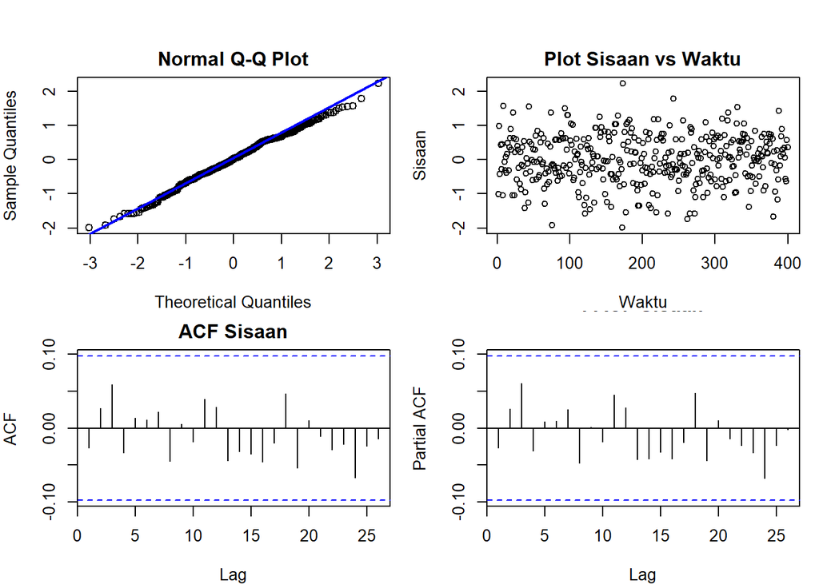

```r
model_terpilih <- model_tambahan # ARIMA(1,1,1)

sisaan.da <- model_terpilih$residuals

par(mfrow = c(2,2), mar = c(4,4,2,1), oma = c(0,0,2,0))

# Q-Q Plot
qqnorm(sisaan.da, main = "Normal Q-Q Plot")
qqline(sisaan.da, col = "blue", lwd = 2)

# Plot Sisaan vs Waktu
plot(sisaan.da, type = "p",
     main = "Plot Sisaan vs Waktu",
     xlab = "Waktu", ylab = "Sisaan")

# ACF
acf(sisaan.da, main = "ACF Sisaan")

# PACF
pacf(sisaan.da, main = "PACF Sisaan")
```

```r
par(mfrow = c(1,1))
```

Berdasarkan plot kuantil-kuantil normal (Normal Q-Q Plot), sisaan menyebar menyusuri garis diagonal acuan $45^\circ$, yang menunjukkan bahwa sisaan berdistribusi normal.Selanjutnya, plot sisaan vs waktu memperlihatkan sebaran poin yang acak di sekitar nilai nol dengan lebar pita konstan, mengindikasikan rataan sisaan sama dengan nol dan ragamnya homogen (homoskedastisitas).Pada plot ACF dan PACF sisaan model $\text{ARIMA}(1,1,1)$, seluruh garis autokorelasi berada di dalam batas garis signifikan 95% (garis putus-putus biru). Hal ini menunjukkan tidak terdapat autokorelasi yang signifikan pada sisaan, sehingga sisaan sudah saling bebas (white noise). Asumsi-asumsi ini selanjutnya akan dikonfirmasi menggunakan uji formal.

### 6.4.2. Uji Formal

```r
# Uji Normalitas Sisaan
shapiro.test(sisaan.da)
```

```
##
##  Shapiro-Wilk normality test
##
## data:  sisaan.da
## W = 0.99561, p-value = 0.3275
```

Selain dengan eksplorasi, asumsi tersebut dapat diuji menggunakan uji formal. Pada tahapan ini, uji formal yang digunakan untuk normalitas adalah uji Shapiro-Wilk. Hipotesis pada uji ini adalah sebagai berikut:

$H_0$ : Sisaan menyebar normal $H_1$ : Sisaan tidak menyebar normal

Berdasarkan uji Shapiro-Wilk tersebut, didapat p-value sebesar 0.3275 yang lebih besar dari taraf nyata $5\%$ ($\alpha = 0.05$) sehingga gagal tolak $H_0$ dan menandakan bahwa sisaan menyebar normal. Hal ini sesuai dengan hasil eksplorasi menggunakan plot kuantil-kuantil normal.

```r
# Sisaan saling bebas/tidak ada autokorelasi
Box.test(sisaan.da, lag = 20, type = "Ljung")
```

```
##
##  Box-Ljung test
##
## data:  sisaan.da
## X-squared = 9.6806, df = 20, p-value = 0.9736
```

Selanjutnya akan dilakukan uji formal untuk kebebasan sisaan menggunakan uji Ljung-Box. Hipotesis yang digunakan adalah sebagai berikut:

$H_0$ : Sisaan saling bebas $H_1$ : Sisaan tidak saling bebas

Berdasarkan uji Ljung-Box tersebut, didapat *p-value* sebesar 0.9736 yang lebih besar dari taraf nyata 5% sehingga gagal tolak $H_0$ dan menandakan bahwa sisaan saling bebas. Hal ini sejalan dengan hasil eksplorasi plot ACF dan PACF sisaan.

```r
# Sisaan Homogen
Box.test((sisaan.da)^2, lag = 20, type = "Ljung")
```

```
##
##  Box-Ljung test
##
## data:  (sisaan.da)^2
## X-squared = 15.747, df = 20, p-value = 0.7322
```

Hipotesis yang digunakan untuk uji kehomogenan ragam adalah sebagai berikut:

$H_0$ : Ragam sisaan homogen $H_1$ : Ragam sisaan tidak homogen

Berdasarkan uji Ljung-Box terhadap sisaan kuadrat tersebut, didapat *p-value* sebesar 0.7322 yang lebih besar dari taraf nyata 5% sehingga gagal tolak $H_0$ dan menandakan bahwa ragam sisaan homogen.

```r
# Nilai tengah sisaan sama dengan nol
t.test(sisaan.da, mu = 0, conf.level = 0.95)
```

```
##
##  One Sample t-test
##
## data:  sisaan.da
## t = 0.02253, df = 398, p-value = 0.982
## alternative hypothesis: true mean is not equal to 0
## 95 percent confidence interval:
##  -0.06885276  0.07044915
## sample estimates:
##    mean of x
## 0.0007981972
```

Terakhir, dengan uji-t, akan dicek apakah nilai tengah sisaan sama dengan nol. Hipotesis yang diujikan sebagai berikut.

$H_0$ : nilai tengah sisaan sama dengan 0 $H_1$ : nilai tengah sisaan tidak sama dengan 0

Berdasarkan uji tersebut, didapat *p-value* sebesar 0.982 yang lebih besar dari taraf nyata 5% sehingga gagal tolak $H_0$ dan menandakan bahwa nilai tengah sisaan sama dengan nol. Hal ini sejalan dengan hasil eksplorasi.

# 7. Overfitting

Tahapan selanjutnya adalah overfitting, yang dilakukan dengan menaikkan orde $\text{AR}(p)$ dan $\text{MA}(q)$ satu tingkat dari model terbaik saat ini, yaitu $\text{ARIMA}(1,1,1)$, untuk menguji apakah penambahan parameter dapat meningkatkan kebaikan model. Kandidat model overfitting yang diuji adalah $\text{ARIMA}(2,1,1)$ (menaikkan orde AR) dan $\text{ARIMA}(1,1,2)$ (menaikkan orde MA).

```r
#---OVERFITTING---#
# Model awal terbaik: ARIMA(1,0,1) pada train.diff
model_awal <- Arima(train.diff, order = c(1,0,1), method = "ML")

# Overfitting 1: Menaikkan AR -> ARIMA(2,0,1)
model_over_ar <- Arima(train.diff, order = c(2,0,1), method = "ML")
summary(model_over_ar)
```

```
## Series: train.diff
## ARIMA(2,0,1) with non-zero mean
##
## Coefficients:
##          ar1     ar2      ma1    mean
##       0.5154  0.0831  -0.9278  0.0019
## s.e.  0.0653  0.0595   0.0407  0.0065
##
## sigma^2 = 0.5022:  log likelihood = -427.12
## AIC=864.24   AICc=864.39   BIC=884.18
##
## Training set error measures:
##                      ME      RMSE       MAE MPE MAPE      MASE         ACF1
## Training set 0.00154488 0.7050897 0.5674236 NaN  Inf 0.5700015 -0.004346788
```

```r
lmtest::coeftest(model_over_ar) # Cek signifikansi parameter ar2
```

```
##
## z test of coefficients:
##
##             Estimate Std. Error  z value  Pr(>|z|)
## ar1        0.5154301  0.0653310   7.8895 3.034e-15 ***
## ar2        0.0831042  0.0594807   1.3972    0.1624
## ma1       -0.9278299  0.0406533 -22.8230 < 2.2e-16 ***
## intercept  0.0019452  0.0065497   0.2970    0.7665
## ---
## Signif. codes:  0 '***' 0.001 '**' 0.01 '*' 0.05 '.' 0.1 ' ' 1
```

```r
# Overfitting 2: Menaikkan MA -> ARIMA(1,0,2)
model_over_ma <- Arima(train.diff, order = c(1,0,2), method = "ML")
summary(model_over_ma)
```

```
## Series: train.diff
## ARIMA(1,0,2) with non-zero mean
##
## Coefficients:
##          ar1      ma1     ma2    mean
##       0.7021  -1.1233  0.1723  0.0018
## s.e.  0.1068   0.1278  0.1016  0.0060
##
## sigma^2 = 0.5015:  log likelihood = -426.87
## AIC=863.74   AICc=863.89   BIC=883.68
##
## Training set error measures:
##                       ME      RMSE       MAE MPE MAPE      MASE        ACF1
## Training set 0.001689243 0.7046108 0.5672261 NaN  Inf 0.5698031 0.003741433
```

```r
lmtest::coeftest(model_over_ma) # Cek signifikansi parameter ma2
```

```
##
## z test of coefficients:
##
##             Estimate Std. Error z value  Pr(>|z|)
## ar1        0.7020785  0.1067773  6.5752  4.86e-11 ***
## ma1       -1.1232971  0.1277855 -8.7905 < 2.2e-16 ***
## ma2        0.1722715  0.1015779  1.6960   0.08989 .
## intercept  0.0018004  0.0060284  0.2987   0.76521
## ---
## Signif. codes:  0 '***' 0.001 '**' 0.01 '*' 0.05 '.' 0.1 ' ' 1
```

```r
overfitting <- data.frame(
  Model = c("ARIMA(2,1,1)", "ARIMA(1,1,1)", "ARIMA(1,1,2)"),
  AIC   = c(AIC(model_over_ar), AIC(model_awal), AIC(model_over_ma)),
  BIC   = c(BIC(model_over_ar), BIC(model_awal), BIC(model_over_ma))
)

overfitting
```

```
##          Model      AIC      BIC
## 1 ARIMA(2,1,1) 864.2376 884.1825
## 2 ARIMA(1,1,1) 864.0494 880.0052
## 3 ARIMA(1,1,2) 863.7352 883.6800
```

Berdasarkan kedua model hasil overfitting di atas, parameter tambahan pada model $\text{ARIMA}(2,1,1)$ (parameter $ar2$, $p\text{-value} = 0.1624$) maupun $\text{ARIMA}(1,1,2)$ (parameter $ma2$, $p\text{-value} = 0.08989$) tidak signifikan pada taraf nyata $5\%$. Selain itu, model $\text{ARIMA}(1,1,1)$ memiliki nilai BIC terkecil ($880.0052$). Oleh karena itu, berdasarkan prinsip parsimoni, model $\text{ARIMA}(1,1,1)$ tetap dipilih sebagai model terbaik untuk melakukan peramalan.

# 8. Peramalan

Peramalan dilakukan menggunakan fungsi forecast(). Peramalan berikut ini dilakukan untuk 100 periode ke depan (sesuai dengan jumlah amatan pada data uji).

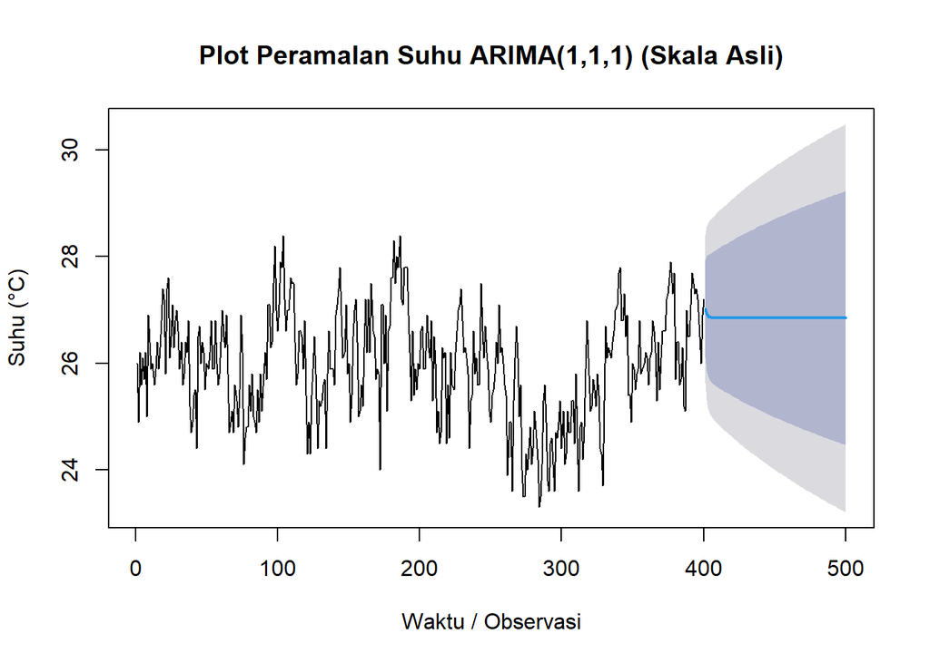

```r
# PERAMALAN (FORECASTING)
library(forecast)
model_terbaik <- Arima(train.ts, order = c(1, 1, 1), method = "ML")

# Peramalan untuk 100 periode ke depan (sesuai panjang data uji)
ramalan_asli <- forecast::forecast(model_terbaik, h = length(test.ts))

# Plot Peramalan Skala Asli Suhu (°C)
plot(ramalan_asli,
     main = "Plot Peramalan Suhu ARIMA(1,1,1) (Skala Asli)",
     xlab = "Waktu / Observasi",
     ylab = "Suhu (°C)")
```

```r
# Menampilkan tabel hasil peramalan
as.data.frame(ramalan_asli)
```

```
##     Point Forecast    Lo 80    Hi 80    Lo 95    Hi 95
## 401       27.02370 26.11552 27.93187 25.63476 28.41263
## 402       26.93581 25.86980 28.00183 25.30549 28.56614
## 403       26.89201 25.75902 28.02500 25.15925 28.62476
## 404       26.87017 25.69894 28.04139 25.07893 28.66140
## 405       26.85928 25.66094 28.05762 25.02658 28.69199
## 406       26.85386 25.63329 28.07442 24.98716 28.72055
## 407       26.85115 25.61072 28.09158 24.95408 28.74823
## 408       26.84981 25.59076 28.10885 24.92426 28.77535
## 409       26.84913 25.57219 28.12608 24.89621 28.80206
## 410       26.84880 25.55442 28.14318 24.86921 28.82838
## 411       26.84863 25.53716 28.16011 24.84291 28.85436
## 412       26.84855 25.52025 28.17684 24.81710 28.88000
## 413       26.84851 25.50363 28.19339 24.79169 28.90532
## 414       26.84849 25.48724 28.20974 24.76663 28.93034
```

[output cut: 86 more lines]

Berdasarkan plot hasil peramalan di atas, dapat dilihat bahwa hasil ramalan model $\text{ARIMA}(1,1,1)$ untuk 100 periode ke depan cenderung mengalami penyesuaian di awal periode kemudian bergerak stabil/konstan hingga akhir periode. Selanjutnya, dapat dicari nilai akurasi antara hasil ramalan dengan data uji sebagai berikut:

```r
# 1. Membuat tabel perbandingan Data Aktual vs Hasil Peramalan (100 Data)
perbandingan <- data.frame(
  Aktual = as.numeric(test.ts),
  Forecast = as.numeric(ramalan_asli$mean)
)
perbandingan
```

```
##     Aktual Forecast
## 1     26.3 27.02370
## 2     25.8 26.93581
## 3     27.4 26.89201
## 4     26.9 26.87017
## 5     25.7 26.85928
## 6     25.0 26.85386
## 7     26.1 26.85115
## 8     26.4 26.84981
## 9     25.7 26.84913
## 10    26.1 26.84880
## 11    26.5 26.84863
## 12    26.8 26.84855
## 13    26.0 26.84851
## 14    26.5 26.84849
```

[output cut: 86 more lines]

```r
# 2. Evaluasi Akurasi Peramalan
accuracy(as.numeric(ramalan_asli$mean), as.numeric(test.ts))
```

```
##                 ME      RMSE       MAE     MPE     MAPE
## Test set 0.3190406 0.7906134 0.6577411 1.10377 2.407744
```

# 9. Kesimpulan

## 9.1. Karakteristik Data & Stasioneritas

- Data suhu rata-rata Kota Bogor (500 observasi) dibagi menjadi data latih (400 observasi) dan data uji (100 observasi).
- Data latih awal sudah stasioner dalam ragam ($\lambda_{\text{optimum}} = 2,4343$; selang kepercayaan $95\%$ memuat angka $1$).
- Untuk mengatasi ketidakstasioneran rataan akibat plot ACF yang meluruh lambat, dilakukan pembedaan pertama (differencing $d=1$). Hasil differencing terbukti stasioner baik dalam rataan ($p\text{-value ADF} = 0,01$) maupun ragam ($\lambda_{\text{optimum}} = 0,8788$).

## 9.2. Pemilihan Model Terbaik

- Berdasarkan eksplorasi plot ACF, PACF, dan EACF, diuji beberapa kandidat model tentatif.
- Model ARIMA(1,1,1) terpilih sebagai model terbaik karena seluruh parameternya signifikan pada taraf nyata $5\%$ ($p\text{-value AR1} = 1,12 \times 10^{-9}$ dan $p\text{-value MA1} < 2,2 \times 10^{-16}$), memiliki nilai BIC terkecil ($880,01$), serta memenuhi prinsip parsimoni.

## 9.3. Uji Diagnostik Sisaan & Overfitting

- Sisaan model ARIMA(1,1,1) telah memenuhi seluruh asumsi model time series baku (white noise):
- Normalitas: Berdistribusi normal (Shapiro-Wilk $p\text{-value} = 0,3275 > 0,05$).
- Kebebasan Sisaan: Bebas dari autokorelasi (Ljung-Box $p\text{-value} = 0,9736 > 0,05$).
- Homogenitas Ragam: Ragam sisaan homogen (Ljung-Box sisaan kuadrat $p\text{-value} = 0,7322 > 0,05$).
- Nilai Tengah Sisaan: Rataan sisaan sama dengan nol ($t\text{-test } p\text{-value} = 0,9820 > 0,05$).
- Tahap overfitting pada model ARIMA(2,1,1) dan ARIMA(1,1,2) menunjukkan bahwa parameter tambahan tidak signifikan secara statistik, mengonfirmasi kestabilan model ARIMA(1,1,1).

## 9.4. Kinerja Peramalan

- Hasil peramalan untuk 100 periode ke depan menunjukkan pola pergerakan yang stabil di sekitar rataan $26,85^\circ\text{C}$.
- Evaluasi terhadap data uji menghasilkan nilai akurasi MAPE sebesar $2,41\%$, RMSE sebesar $0,79$, dan MAE sebesar $0,66$. Karena nilai MAPE jauh di bawah $10\%$, model ARIMA(1,1,1) memiliki kemampuan peramalan dengan tingkat akurasi yang sangat tinggi (highly accurate forecast).